# HOMICIDE – A CONCERN ACROSS DEMOGRAPHY?

Vani Duggal, Mehak Khanna, Manon Pillot, Liyang Zhang, Tobias Delago

2022-11-23

# 1 Research Questions

> When selecting our Global Experience (GE) destination, the topic “safety” was also an important factor (especially for our parents). Finding it very intriguing, we set out to conduct our own analysis on Homicides across demography.

> *− What classifies as homicide?*

> *− Are homicides a major cause of death?*

> *− How do homicide counts vary (time/place)?*

> *− Can homicide rates be predicted?*

> *− Does victim gender play a role?*

# 2 Our methodology

> *− Started by reading and learning about the topic and exploring data setsaround the former.*

> *- Inspected the various data sets, cleaned them by filtering, formatting andimputing the NA values.*

> *- Designed bar graphs, maps, box-plots, scatter plots and flow charts on R,for each research question.*

> *- Created multiple linear regression model to predict homicides using worlddevelopment indicators.*

> *- Exported files and compiled them on poster. Used additional software to addvisual features to plots.*

# 3 Code for the project

## 3.1 import data

```r
# import world death causes data
data_1 <- readr::read_csv('data/annual-number-of-deaths-by-cause.csv')
# import 15-49 age group world death causes data
data_2 <- readr::read_csv('data/causes-of-death-in-15-49-year-olds.csv')
# import world countries population data
data_pop <- read_csv("data/pop.csv")
# import world countries homicide cases amount data
data_hm_n <- read_csv(file = "data/homicide_count.csv")
# import world homicide rate data
homicide_raw <- vroom("data/homicide-rate-1990-vs-2019.csv")
# import world continent homicide rate data
homicide_raw_long <- vroom("data/data_countries.csv")
# import world bank and economic data
world_bank <- vroom("data/world_bank_data.csv")
# import world happiness data & download data to temporary file
url <- "https://happiness-report.s3.amazonaws.com/2021/DataPanelWHR2021C2.xls"
httr::GET(url, write_disk(happiness.temp <- tempfile(fileext = ".xls")))
```

```
## Response [https://happiness-report.s3.amazonaws.com/2021/DataPanelWHR2021C2.xls]
##   Date: 2022-11-23 09:27
##   Status: 200
##   Content-Type: application/vnd.ms-excel
##   Size: 435 kB
## <ON DISK>  C:\Users\OLIVIE~1\AppData\Local\Temp\Rtmpe2iAkT\file1b668493637e.xls
```

```r
# import data with information for victim and the affected age group
victim_age_data <- read.csv("data/data_countries_age.csv")
# import data for intentional homicide
intentional_homicide_data_all <- read.csv("data/data_cts_intentional_homicide.csv")
```

## 3.2 Summary for the following 3 bar charts

> *Around 60 million people die every year. As expected, a majority of these are attributable to natural causes of death.*

> *Limiting the scope to the age group between 15-49 years, we can observe that the gap between cardiovascular diseases, cancers and the other causes starts to shrink.*

> *On the rightmost figure homicide becomes the major death cause in 2019. The same is true for other 11 countries, all (!) of which lie in Central/ South America.*

### 3.2.1 Human unnatural death rank

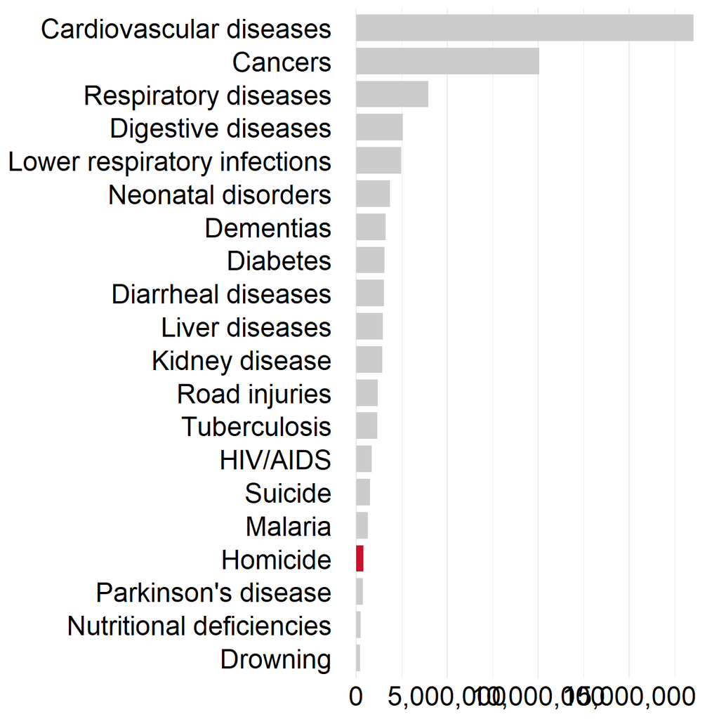

```r
# Select data needed
graph_1 <- data_1 %>%
           filter(Year == "2019") %>%
           filter(Entity == "World") %>%
           rename(Meningitis = `Deaths - Meningitis - Sex: Both - Age: All Ages (Number)`,
            Dementias = `Deaths - Alzheimer's disease and other dementias - Sex: Both - Age: All Ages (Number)`,
            "Cardiovascular diseases" = `Deaths - Cardiovascular diseases - Sex: Both - Age: All Ages (Number)`,
            "Parkinson's disease" = `Deaths - Parkinson's disease - Sex: Both - Age: All Ages (Number)`,
            "Nutritional deficiencies" = `Deaths - Nutritional deficiencies - Sex: Both - Age: All Ages (Number)`,
            Malaria = `Deaths - Malaria - Sex: Both - Age: All Ages (Number)`,
            Drowning = `Deaths - Drowning - Sex: Both - Age: All Ages (Number)`,
            Homicide = `Deaths - Interpersonal violence - Sex: Both - Age: All Ages (Number)`,
            "Maternal disorders" = `Deaths - Maternal disorders - Sex: Both - Age: All Ages (Number)`,
            "HIV/AIDS" = `Deaths - HIV/AIDS - Sex: Both - Age: All Ages (Number)`,
            "Drug use disorders" = `Deaths - Drug use disorders - Sex: Both - Age: All Ages (Number)`,
            Tuberculosis = `Deaths - Tuberculosis - Sex: Both - Age: All Ages (Number)`,
            "Lower respiratory infections" = `Deaths - Lower respiratory infections - Sex: Both - Age: All Ages (Number)`,
            "Neonatal disorders" = `Deaths - Neonatal disorders - Sex: Both - Age: All Ages (Number)`,
            "Alcohol use disorders" = `Deaths - Alcohol use disorders - Sex: Both - Age: All Ages (Number)`,
            "Kidney disease" = `Deaths - Chronic kidney disease - Sex: Both - Age: All Ages (Number)`,
            Suicide = `Deaths - Self-harm - Sex: Both - Age: All Ages (Number)`,
            "Natural disasters" = `Deaths - Exposure to forces of nature - Sex: Both - Age: All Ages (Number)`,
            "Diarrheal diseases" = `Deaths - Diarrheal diseases - Sex: Both - Age: All Ages (Number)`,
            Heat = `Deaths - Environmental heat and cold exposure - Sex: Both - Age: All Ages (Number)`,
            Cancers = `Deaths - Neoplasms - Sex: Both - Age: All Ages (Number)`,
            Conflict = `Deaths - Conflict and terrorism - Sex: Both - Age: All Ages (Number)`,
            Diabetes = `Deaths - Diabetes mellitus - Sex: Both - Age: All Ages (Number)`,
            Poisonings = `Deaths - Poisonings - Sex: Both - Age: All Ages (Number)`,
            Hepatitis = `Deaths - Acute hepatitis - Sex: Both - Age: All Ages (Number)`,
            "Protein-energy malnutrition" = `Deaths - Protein-energy malnutrition - Sex: Both - Age: All Ages (Number)`,
            "Road injuries" = `Deaths - Road injuries - Sex: Both - Age: All Ages (Number)`,
            "Respiratory diseases" = `Deaths - Chronic respiratory diseases - Sex: Both - Age: All Ages (Number)`,
            "Liver diseases" = `Deaths - Cirrhosis and other chronic liver diseases - Sex: Both - Age: All Ages (Number)`,
            "Digestive diseases" = `Deaths - Digestive diseases - Sex: Both - Age: All Ages (Number)`,
            Fire = `Deaths - Fire, heat, and hot substances - Sex: Both - Age: All Ages (Number)`) %>%
            select(Meningitis, "Maternal disorders", Hepatitis, Suicide, Homicide, Drowning, Malaria, Fire, Cancers, "Digestive diseases", "Liver diseases", "Alcohol use disorders", "Respiratory diseases", "Kidney disease", "Cardiovascular diseases", "Drug use disorders", "Nutritional deficiencies", "Lower respiratory infections", Diabetes, "Protein-energy malnutrition", Heat, "Diarrheal diseases", "Road injuries", Tuberculosis, "HIV/AIDS", "Parkinson's disease", "Neonatal disorders", Conflict, Poisonings, Dementias, "Natural disasters") %>%
            pivot_longer(everything()) %>%
            rename(Cause_of_Death = name,
                   Total = value) %>%
            mutate(Homicide = ifelse(Cause_of_Death == "Homicide", TRUE, FALSE)) %>%
            slice_max(Total, n = 20)

#define colours to use: grey for everything, tomato for controlled drugs
my_colours <- c("grey80", "#CB102D")

#create plot
graph_1_svg <- ggplot(graph_1, aes(x=fct_reorder(Cause_of_Death, Total, max),
                y = Total,
                fill = Homicide))+
       scale_fill_manual(values = my_colours)+
       geom_bar(stat = "identity", show.legend = FALSE, width = 0.8)+
       theme_minimal()+
       scale_y_continuous(labels=comma)+
       coord_flip()+

#labels
  labs(x = '',
       y = 'Number of death')+
  theme(axis.title.x = element_blank(),
        axis.title.y = element_blank(),
        axis.text.y=element_text(color = "black", size = 18),
        axis.text.x=element_text(color = "black", size = 18),
        text=element_text(family="Roboto"),
        legend.position = "none",
        panel.grid.major.y = element_blank(),
        )

graph_1_svg
```

```r
ggsave(file="graph_1.svg", plot=graph_1_svg, width=9, height=9)
```

### 3.2.2 Human unnatural death rank in 15-49 age group

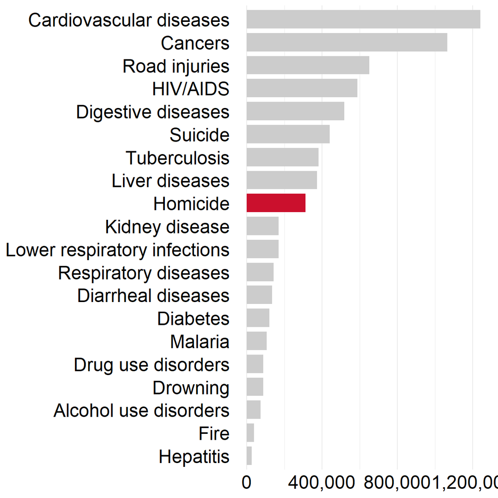

```r
# Select data needed
graph_2 <- data_2 %>%
           filter(Year == "2019") %>%
           filter(Entity == "World") %>%
          rename(Hepatitis = `Deaths - Acute hepatitis - Sex: Both - Age: 15-49 years (Number)`,
            Suicide = `Deaths - Self-harm - Sex: Both - Age: 15-49 years (Number)`,
            Homicide = `Deaths - Interpersonal violence - Sex: Both - Age: 15-49 years (Number)`,
            Drowning = `Deaths - Drowning - Sex: Both - Age: 15-49 years (Number)`,
            Malaria = `Deaths - Malaria - Sex: Both - Age: 15-49 years (Number)`,
            Fire = `Deaths - Fire, heat, and hot substances - Sex: Both - Age: 15-49 years (Number)`,
            Cancers = `Deaths - Neoplasms - Sex: Both - Age: 15-49 years (Number)`,
            "Digestive diseases" = `Deaths - Digestive diseases - Sex: Both - Age: 15-49 years (Number)`,
            "Alcohol use disorders" = `Deaths - Alcohol use disorders - Sex: Both - Age: 15-49 years (Number)`,
            "Liver diseases" = `Deaths - Cirrhosis and other chronic liver diseases - Sex: Both - Age: 15-49 years (Number)`,
            "Respiratory diseases" = `Deaths - Chronic respiratory diseases - Sex: Both - Age: 15-49 years (Number)`,
            "Kidney disease" = `Deaths - Chronic kidney disease - Sex: Both - Age: 15-49 years (Number)`,
            "Cardiovascular diseases" = `Deaths - Cardiovascular diseases - Sex: Both - Age: 15-49 years (Number)`,
            "Drug use disorders" = `Deaths - Drug use disorders - Sex: Both - Age: 15-49 years (Number)`,
            "Nutritional deficiencies" = `Deaths - Nutritional deficiencies - Sex: Both - Age: 15-49 years (Number)`,
            "Lower respiratory infections" = `Deaths - Lower respiratory infections - Sex: Both - Age: 15-49 years (Number)`,
            Diabetes = `Deaths - Diabetes mellitus - Sex: Both - Age: 15-49 years (Number)`,
            "Protein-energy malnutrition" = `Deaths - Protein-energy malnutrition - Sex: Both - Age: 15-49 years (Number)`,
            "Natural disasters" = `Deaths - Exposure to forces of nature - Sex: Both - Age: 15-49 years (Number)`,
            Heat = `Deaths - Environmental heat and cold exposure - Sex: Both - Age: 15-49 years (Number)`,
            "Diarrheal diseases" = `Deaths - Diarrheal diseases - Sex: Both - Age: 15-49 years (Number)`,
            "Road injuries" = `Deaths - Road injuries - Sex: Both - Age: 15-49 years (Number)`,
            Tuberculosis = `Deaths - Tuberculosis - Sex: Both - Age: 15-49 years (Number)`,
            "HIV/AIDS" = `Deaths - HIV/AIDS - Sex: Both - Age: 15-49 years (Number)`,
            Dementias = `Deaths - Alzheimer's disease and other dementias - Sex: Both - Age: 15-49 years (Number)`,
            "Parkinson's disease" = `Deaths - Parkinson's disease - Sex: Both - Age: 15-49 years (Number)`) %>%
            select(Hepatitis, Suicide, Homicide, Drowning, Malaria, Fire, Cancers, "Digestive diseases", "Liver diseases", "Alcohol use disorders", "Respiratory diseases", "Kidney disease", "Cardiovascular diseases", "Drug use disorders", "Nutritional deficiencies", "Lower respiratory infections", Diabetes, "Protein-energy malnutrition", Heat, "Diarrheal diseases", "Road injuries", Tuberculosis, "HIV/AIDS", "Parkinson's disease", "Natural disasters") %>%
            pivot_longer(everything()) %>%
            rename(Cause_of_Death = name,
                   Total = value) %>%
            mutate(Homicide = ifelse(Cause_of_Death == "Homicide", TRUE, FALSE)) %>%
            slice_max(Total, n = 20)

#define colours to use: grey for everything, tomato for controlled drugs
my_colours <- c("grey80", "#CB102D")

#create plot
graph_2_svg <- ggplot(graph_2, aes(x=fct_reorder(Cause_of_Death, Total, max),
                y = Total,
                fill = Homicide))+
       scale_fill_manual(values = my_colours)+
       geom_bar(stat = "identity", show.legend = FALSE, width = 0.8)+
       theme_minimal()+
       scale_y_continuous(labels=comma)+
       coord_flip()+

#labels
  labs(x = '',
       y = 'Number of death')+
  theme(axis.title.x = element_blank(),
        axis.title.y = element_blank(),
        axis.text.y=element_text(color = "black", size = 18),
        axis.text.x=element_text(color = "black", size = 18),
        text=element_text(family="Roboto"),
        legend.position = "none",
        panel.grid.major.y = element_blank(),
        )


graph_2_svg
```

```r
ggsave(file="graph_2.svg", plot=graph_2_svg, width=9, height=9)
```

### 3.2.3 Homicide amount in Columbia

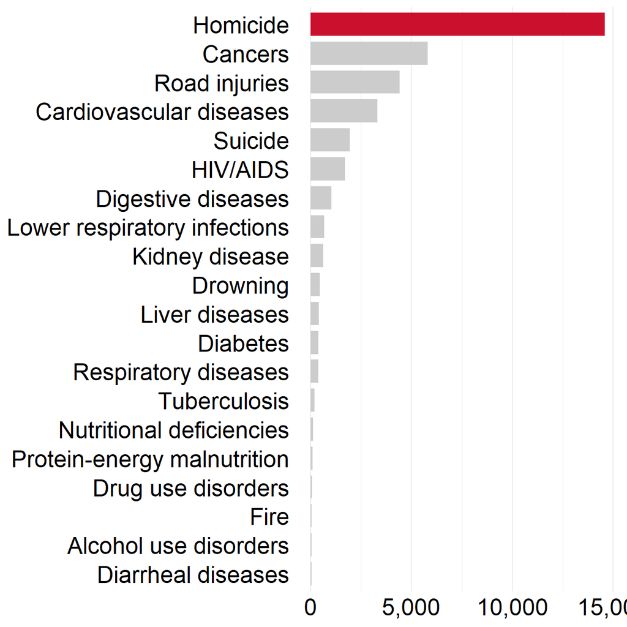

```r
# Select data needed
graph_3 <- data_2 %>%
           filter(Year == "2019") %>%
           filter(Entity == "Colombia") %>%
          rename(Hepatitis = `Deaths - Acute hepatitis - Sex: Both - Age: 15-49 years (Number)`,
            Suicide = `Deaths - Self-harm - Sex: Both - Age: 15-49 years (Number)`,
            Homicide = `Deaths - Interpersonal violence - Sex: Both - Age: 15-49 years (Number)`,
            Drowning = `Deaths - Drowning - Sex: Both - Age: 15-49 years (Number)`,
            Malaria = `Deaths - Malaria - Sex: Both - Age: 15-49 years (Number)`,
            Fire = `Deaths - Fire, heat, and hot substances - Sex: Both - Age: 15-49 years (Number)`,
            Cancers = `Deaths - Neoplasms - Sex: Both - Age: 15-49 years (Number)`,
            "Digestive diseases" = `Deaths - Digestive diseases - Sex: Both - Age: 15-49 years (Number)`,
            "Alcohol use disorders" = `Deaths - Alcohol use disorders - Sex: Both - Age: 15-49 years (Number)`,
            "Liver diseases" = `Deaths - Cirrhosis and other chronic liver diseases - Sex: Both - Age: 15-49 years (Number)`,
            "Respiratory diseases" = `Deaths - Chronic respiratory diseases - Sex: Both - Age: 15-49 years (Number)`,
            "Kidney disease" = `Deaths - Chronic kidney disease - Sex: Both - Age: 15-49 years (Number)`,
            "Cardiovascular diseases" = `Deaths - Cardiovascular diseases - Sex: Both - Age: 15-49 years (Number)`,
            "Drug use disorders" = `Deaths - Drug use disorders - Sex: Both - Age: 15-49 years (Number)`,
            "Nutritional deficiencies" = `Deaths - Nutritional deficiencies - Sex: Both - Age: 15-49 years (Number)`,
            "Lower respiratory infections" = `Deaths - Lower respiratory infections - Sex: Both - Age: 15-49 years (Number)`,
            Diabetes = `Deaths - Diabetes mellitus - Sex: Both - Age: 15-49 years (Number)`,
            "Protein-energy malnutrition" = `Deaths - Protein-energy malnutrition - Sex: Both - Age: 15-49 years (Number)`,
            "Natural disasters" = `Deaths - Exposure to forces of nature - Sex: Both - Age: 15-49 years (Number)`,
            Heat = `Deaths - Environmental heat and cold exposure - Sex: Both - Age: 15-49 years (Number)`,
            "Diarrheal diseases" = `Deaths - Diarrheal diseases - Sex: Both - Age: 15-49 years (Number)`,
            "Road injuries" = `Deaths - Road injuries - Sex: Both - Age: 15-49 years (Number)`,
            Tuberculosis = `Deaths - Tuberculosis - Sex: Both - Age: 15-49 years (Number)`,
            "HIV/AIDS" = `Deaths - HIV/AIDS - Sex: Both - Age: 15-49 years (Number)`,
            Dementias = `Deaths - Alzheimer's disease and other dementias - Sex: Both - Age: 15-49 years (Number)`,
            "Parkinson's disease" = `Deaths - Parkinson's disease - Sex: Both - Age: 15-49 years (Number)`) %>%
            select(Hepatitis, Suicide, Homicide, Drowning, Malaria, Fire, Cancers, "Digestive diseases", "Liver diseases", "Alcohol use disorders", "Respiratory diseases", "Kidney disease", "Cardiovascular diseases", "Drug use disorders", "Nutritional deficiencies", "Lower respiratory infections", Diabetes, "Protein-energy malnutrition", "Natural disasters", Heat, "Diarrheal diseases", "Road injuries", "Tuberculosis", "HIV/AIDS", Dementias, "Parkinson's disease") %>%
            pivot_longer(everything()) %>%
            rename(Cause_of_Death = name,
                   Total = value) %>%
            mutate(Homicide = ifelse(Cause_of_Death == "Homicide", TRUE, FALSE)) %>%
            slice_max(Total, n = 20)

#define colours to use: grey for everything, tomato for controlled drugs
my_colours <- c("grey80", "#CB102D")

#create plot
graph_3_svg <- ggplot(graph_3, aes(x=fct_reorder(Cause_of_Death, Total, max),
                y = Total,
                fill = Homicide))+
       scale_fill_manual(values = my_colours)+
       geom_bar(stat = "identity", show.legend = FALSE, width = 0.8)+
       theme_minimal()+
       scale_y_continuous(labels=comma)+
       coord_flip()+

#labels
  labs(x = '',
       y = 'Number of death')+
  theme(axis.title.x = element_blank(),
        axis.title.y = element_blank(),
        axis.text.y=element_text(color = "black", size = 18),
        axis.text.x=element_text(color = "black", size = 18),
        text=element_text(family="Roboto"),
        legend.position = "none",
        panel.grid.major.y = element_blank(),
        )

graph_3_svg
```

```r
ggsave(file="graph_3.svg", plot=graph_3_svg, width=9, height=9)
```

## 3.3 Summary for the following maps, bar-charts and box-plot.

> *Brazil, India, Mexico, and Russia account for most homicides. The Americas are the continent with most homicides while it is interesting to note that Africa took the second spot, despite not having a dark shade on most countries.*

> *The high population of Brazil and India reduced the rate compared to other countries (top graph). Central America now accounts for countries taking the top spots. Europe’s narrow box-plot shows that rates are particularly uniformly distribute.*

### 3.3.1 Total word countries homicide case amount

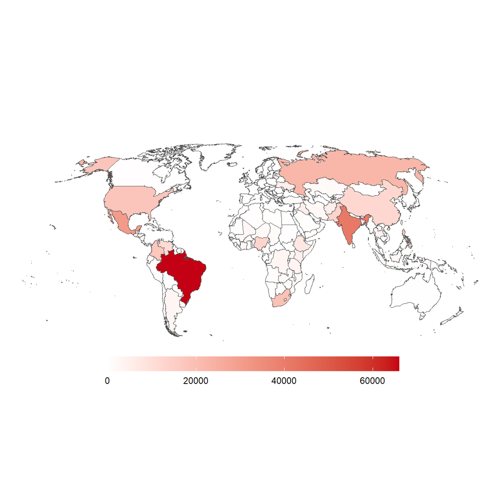

```r
# clean map and population data
map <- ne_countries(scale = "medium", returnclass = "sf") %>%
  dplyr::select(name, iso_a3, geometry) %>%
  filter(!name %in% c("Antarctica"))
data_pop<- data_pop %>%
  clean_names() %>%
  rename(country=country_name, pop=x2019, code =country_code)

# left join map and pop data
map_pop<-map %>%
  rename(country=name, code=iso_a3) %>%
  left_join(data_pop %>%
             select(pop,country), by ="country") %>%
  left_join(data_pop %>% select(pop,code), by = "code")%>%
  mutate(popu= if_else(is.na(pop.x),0,pop.x)+if_else(is.na(pop.y),0,pop.y) -
           if_else((!is.na(pop.x)&!is.na(pop.y)),pop.x,0)) %>%
  mutate(pop = if_else(popu==0, as.numeric(NA), popu)) %>%
  select(-pop.x, -pop.y,-popu)

# clean word countries homicide case amount data
data_n <-data_hm_n %>%
  clean_names() %>%
  filter(year=="2019") %>%
  rename(country=d)

# left join it with population data
df_count1 <- map_pop %>%
  left_join(
    data_n %>%
      select(country,value), by =  "country")
df_count2<-df_count1 %>%
  filter(is.na(code)==FALSE) %>%
  left_join(
  data_n %>% select(code, value), by =  "code") %>%
  rename(value=value.y) %>%
  st_drop_geometry()
df_count<- df_count1 %>%
  left_join(df_count2 %>% select (country,value ), by ="country") %>%
  mutate(value1= if_else(is.na(value.x),0,value.x+0.001)+if_else(is.na(value.y),0,value.y+0.001)   - if_else((!is.na(value.x)&!is.na(value.y)),value.x+0.001,0)) %>%
  mutate(value = if_else(value1==0, as.numeric(NA), round(value1))) %>%
  select(-value1, -value.x, -value.y)

# mutate homicide rate data
df_rate <- df_count %>%
  mutate(value_rate= 100000*value/pop)

# draw map for amount
base_map <- ggplot(data = df_count) +
  geom_sf(
    mapping = aes(
      geometry = geometry, #use Natural Earth World boundaries
      fill = value
    ),
    colour = "#4c4c4c",      # white borders between regions
  )+
  scale_fill_gradient(
    low = "#ffffff",
    high = '#c40014',
    na.value = "white")+
  labs(
    title = "", fill=""
  )+
  theme_void()+
  coord_sf(crs = "+proj=robin")+
  theme(legend.position="bottom",
          legend.direction = "horizontal", legend.key.size = unit(0.5, "cm"),
  legend.key.width = unit(2,"cm") )+
  NULL
base_map
```

### 3.3.2 Total word countries homicide rate(per 100000 people) in 2019

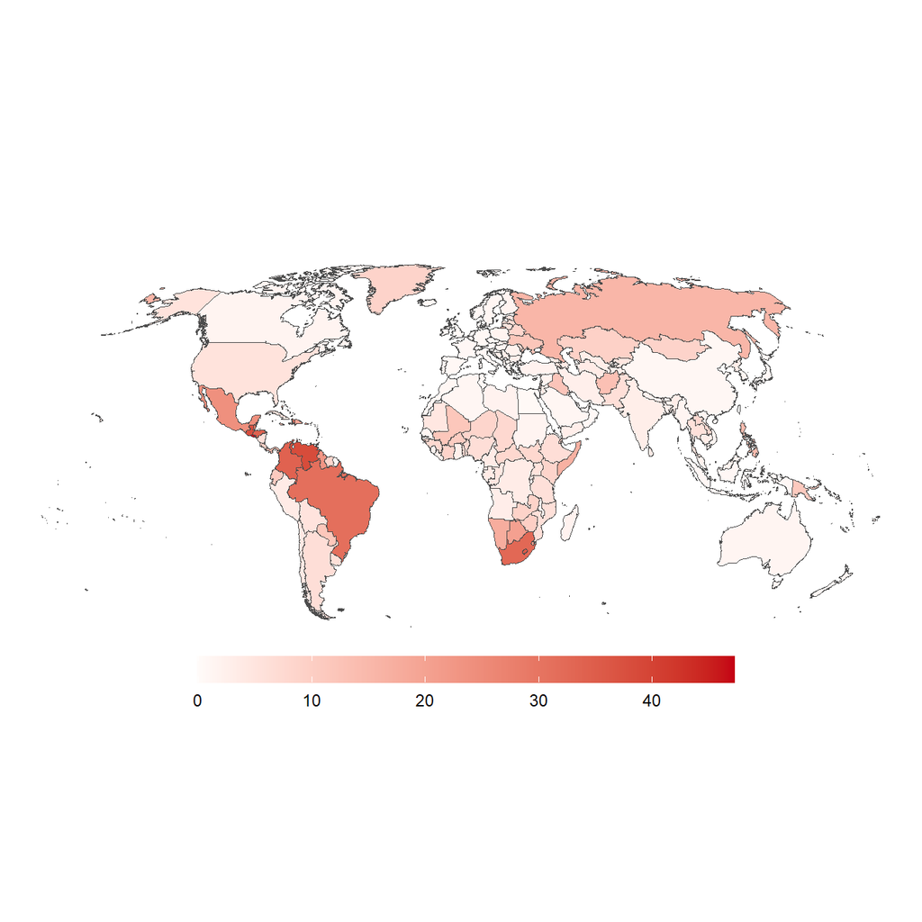

```r
# draw map for rate
base_map_rate <- ggplot(data = df_rate) +
  geom_sf(
    mapping = aes(
      geometry = geometry, #use Natural Earth World boundaries
      fill = value_rate
    ),
     colour = "#4c4c4c",      # white borders between regions
  )+
  scale_fill_gradient(
    low = "#fffbf9",
    high = '#c40014',
    na.value = "white")+
  labs(
    title = "", fill=""
  )+
  theme_void()+
  coord_sf(crs = "+proj=robin")+
  theme(legend.position="bottom",
          legend.direction = "horizontal", legend.key.size = unit(0.5, "cm"),
  legend.key.width = unit(2,"cm") )+
  NULL

base_map_rate
```

### 3.3.3 Crosses global experience continents homicide rates and cases amount compare

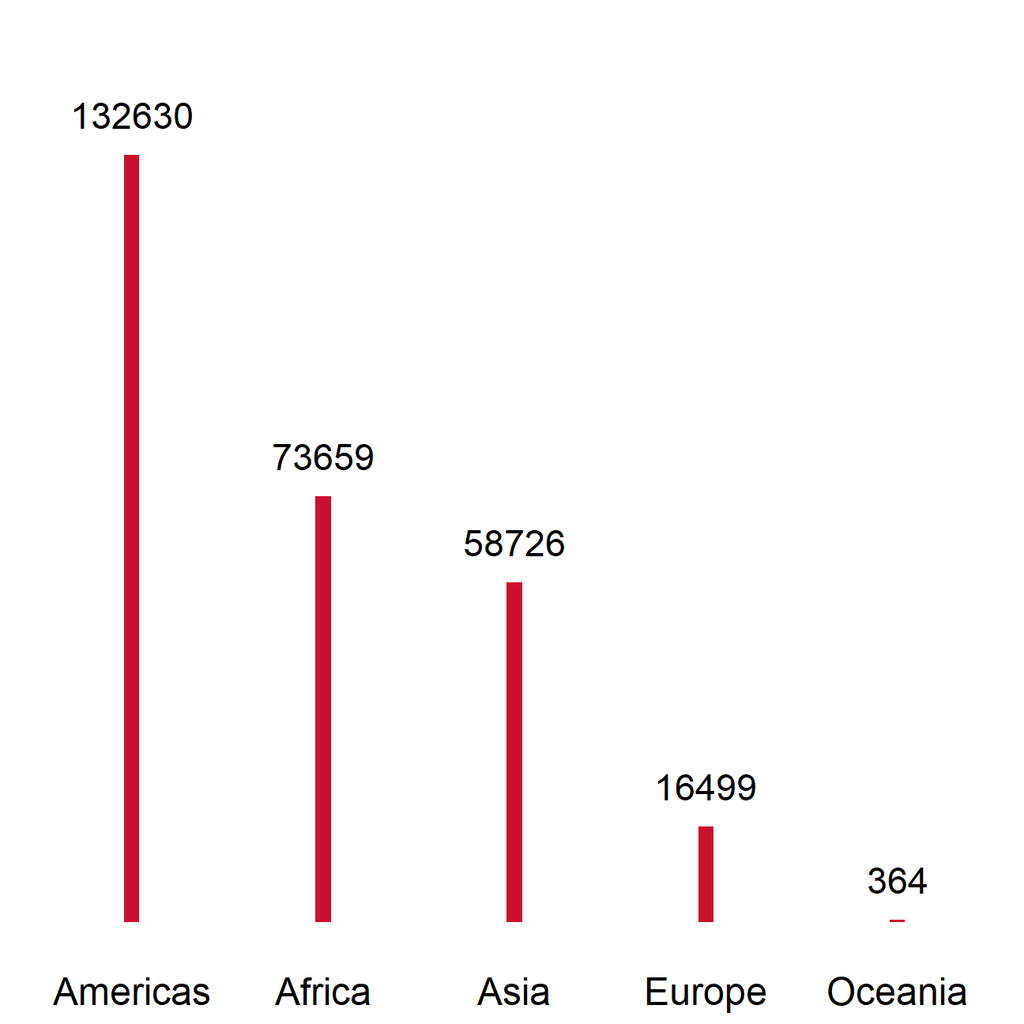

```r
# clean data
homicide_raw_long <-homicide_raw_long%>%
  clean_names()

#select relevant continents
continents <- c("Europe", "Asia", "Americas", "Oceania", "Africa")

#filter all the data
homicide_continents <- homicide_raw_long %>%
  filter(year == 2019) %>%
  filter(dimension == "Total") %>%
  filter(indicator == "Victims of intentional homicide") %>%
  filter(sex == "Total") %>%
  filter(age == "Total") %>%
  filter(region %in% continents) %>%
  filter(unit_of_measurement == "Counts") %>%
  group_by(region) %>%
  summarize(homicide_count = sum(value)) %>%
  mutate(region = fct_reorder(region, homicide_count, .desc = TRUE))

#plot counts
counts_continent_plot <- homicide_continents %>%
  ggplot(aes(x = region, y = homicide_count))+
  geom_text(aes(x=region, y=homicide_count, label = homicide_count), size = 6, vjust = -1)+
  geom_col(fill = "#CB102D", width = 0.08)+
  theme_minimal()+
  theme(axis.title.x = element_blank(),
        axis.title.y = element_blank(),
        axis.text.y=element_blank(),
        axis.text.x=element_text(color = "black", size = 18),
        text=element_text(family="Roboto"),
        panel.grid = element_blank(),
        plot.caption = element_text(color = "grey", hjust = 0, vjust = -5),
        )+
  ylim(0,150000)

counts_continent_plot
```

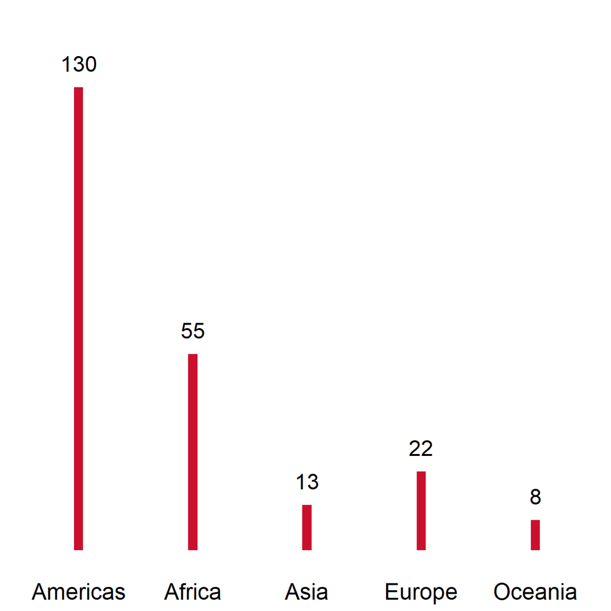

```r
# add population per continent and calculate rate
homicide_continents_prop <- homicide_continents %>%
  mutate(population = c(1340598147, 1022831978, 4641054775, 747636026, 43111704)) %>%
  mutate(homicide_rate = homicide_count/population * 1000000) %>%
  mutate(region = fct_reorder(region, homicide_count, .desc = TRUE))


# plot it

rate_continent_plot <- homicide_continents_prop %>%
  ggplot(aes(x = region, y = homicide_rate))+
  geom_col(fill = "#CB102D", width = 0.08)+
  geom_text(aes(x=region, y=homicide_rate, label = round(homicide_rate,0)), size = 6, vjust = -1)+
  theme_minimal()+
  theme(axis.title.x = element_blank(),
        axis.title.y = element_blank(),
        axis.text.y=element_blank(),
        axis.text.x=element_text(color = "black", size = 18),
        text=element_text(family="Roboto"),
        panel.grid = element_blank(),
        plot.caption = element_text(color = "grey", hjust = 0, vjust = -5),
        )+
  ylim(0,145)

rate_continent_plot
```

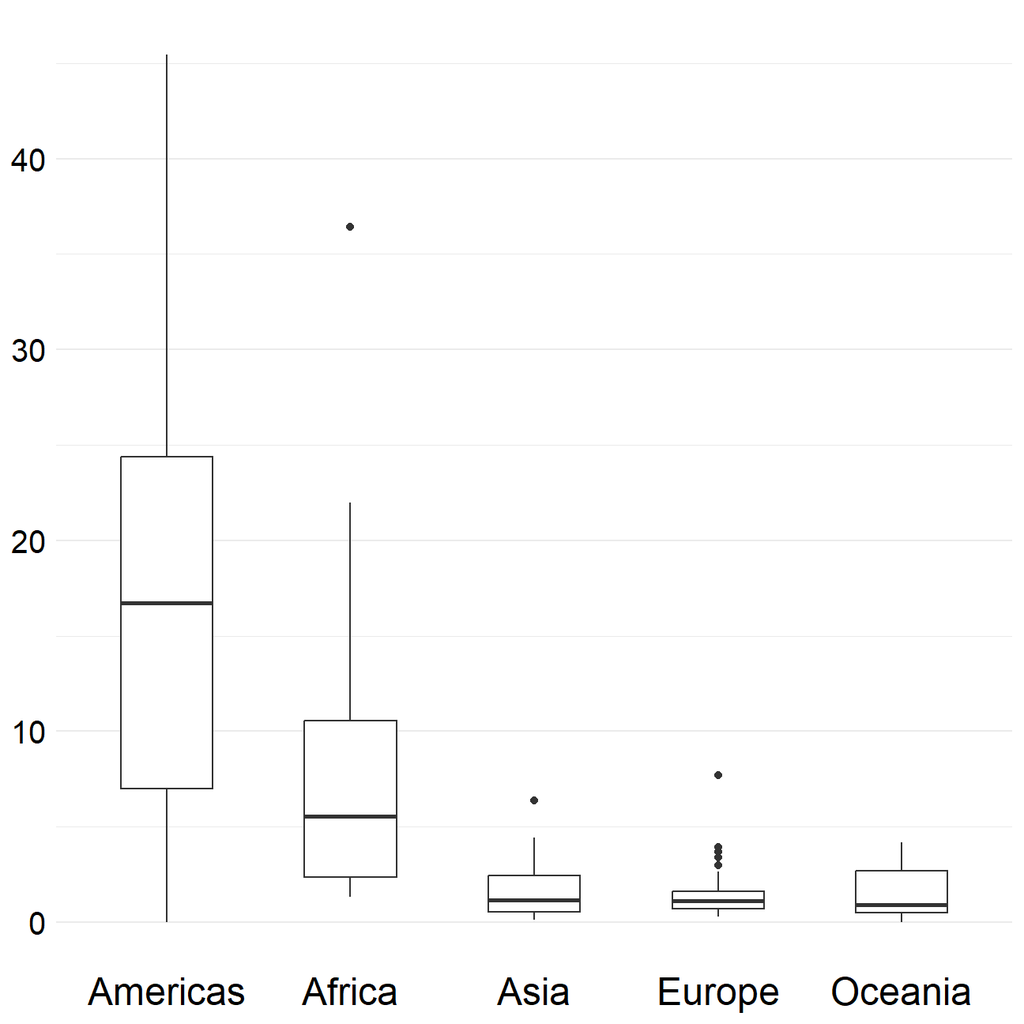

```r
# Save files
ggsave(file="count.svg", plot=counts_continent_plot, width=8, height=4)
ggsave(file="rate.svg", plot=rate_continent_plot, width=8, height=4)


# Boxplots for distribution

homicide_continents_box <- homicide_raw_long %>%
  filter(year == 2019) %>%
  filter(dimension == "Total") %>%
  filter(indicator == "Victims of intentional homicide") %>%
  filter(sex == "Total") %>%
  filter(age == "Total") %>%
  filter(region %in% continents) %>%
  filter(unit_of_measurement == "Rate per 100,000 population")

box_rate <- homicide_continents_box %>%
  ggplot(aes(x = reorder(region, -value, FUN = median), y = value)) +
  geom_boxplot(width = 0.5)+
  theme_minimal()+
  theme(axis.title.x = element_blank(),
        axis.title.y = element_blank(),
        axis.text.x=element_text(color = "black", size = 18),
        axis.text.y=element_text(color = "black", size = 15),
        text=element_text(family="Roboto"),
        panel.grid.major.x = element_blank(),
        )

box_rate
```

```r
ggsave(file="box.svg", plot=box_rate, width=9, height=3.7)

  #group_by(region) %>%
  #summarize(homicide_count = sum(value)) %>%
  #mutate(region = fct_reorder(region, homicide_count, .desc = TRUE))
```

## 3.4 Summary for the homicide prediction models

> *National homicide rates on a global level are very difficult to predict as they are determined by many complex interrelations. In fact, extensive internet research did not reveal any plausible model.*

### 3.4.1 Prediction homicide rate models

```r
# clean world bank data ------------------------
world_bank <-world_bank %>%
  janitor::clean_names() %>%
  mutate(value = as.double(value)) %>%
  filter(series_name == "GDP per capita (current US$)") %>%
  dplyr::select(code, value)

# Use read_excel to read world happiness data as dataframe
world_happiness <- read_excel(happiness.temp,
                    sheet = "Sheet1",
                    range = cell_cols("A:K")) %>%
  janitor::clean_names()
world_happiness <- world_happiness %>%
  filter(year == 2019)

# clean data
homicide_raw<- homicide_raw %>%  clean_names()
glimpse(homicide_raw)
```

```
## Rows: 6,921
## Columns: 7
## $ entity                                                             <chr> "Ab…
## $ code                                                               <chr> "OW…
## $ year_3                                                             <dbl> 201…
## $ deaths_interpersonal_violence_sex_both_age_age_standardized_rate_4 <dbl> NA,…
## $ continent                                                          <chr> "As…
## $ deaths_interpersonal_violence_sex_both_age_age_standardized_rate_6 <dbl> NA,…
## $ year_7                                                             <dbl> NA,…
```

```r
# filter for 2019
homicide_linear <- homicide_raw %>%
  rename(year = year_3) %>%
  rename(homicide_rate = deaths_interpersonal_violence_sex_both_age_age_standardized_rate_4) %>%
  rename(country = entity) %>%
  select(country, code, year, homicide_rate) %>%
  filter(year == 2019) %>%
  filter(!is.na(code))

# joining tables
homicide_happiness <- inner_join(homicide_linear, world_happiness, by = c("country" = "country_name"))
homicide_happiness <- homicide_happiness %>%
  select(-year.x, -year.y, -positive_affect, -negative_affect)

homicide_happiness_gdp <- inner_join(homicide_happiness, world_bank, by = "code")

homicide_happiness_gdp <- homicide_happiness_gdp %>%
  rename(gdp_percap = value)

# own model
model_happiness <- lm(log1p(homicide_rate) ~ life_ladder, data = homicide_happiness_gdp)
summary(model_happiness)
```

```
##
## Call:
## lm(formula = log1p(homicide_rate) ~ life_ladder, data = homicide_happiness_gdp)
##
## Residuals:
##    Min     1Q Median     3Q    Max
## -1.450 -0.617 -0.274  0.534  2.551
##
## Coefficients:
##             Estimate Std. Error t value Pr(>|t|)
## (Intercept)   3.0163     0.3664    8.23  1.4e-13 ***
## life_ladder  -0.2621     0.0644   -4.07  8.0e-05 ***
## ---
## Signif. codes:  0 '***' 0.001 '**' 0.01 '*' 0.05 '.' 0.1 ' ' 1
##
## Residual standard error: 0.845 on 134 degrees of freedom
## Multiple R-squared:  0.11,   Adjusted R-squared:  0.103
## F-statistic: 16.6 on 1 and 134 DF,  p-value: 7.96e-05
```

```r
reduced <- homicide_happiness_gdp %>%
  dplyr::select(-life_ladder,-country, -code)

reduced<-na.omit(reduced)

model <- lm(log1p(homicide_rate) ~ healthy_life_expectancy_at_birth + social_support +
              freedom_to_make_life_choices + generosity+gdp_percap, data = reduced)
summary(model)
```

```
##
## Call:
## lm(formula = log1p(homicide_rate) ~ healthy_life_expectancy_at_birth +
##     social_support + freedom_to_make_life_choices + generosity +
##     gdp_percap, data = reduced)
##
## Residuals:
##     Min      1Q  Median      3Q     Max
## -1.1917 -0.4902 -0.0446  0.3851  2.1533
##
## Coefficients:
##                                   Estimate Std. Error t value Pr(>|t|)
## (Intercept)                       4.57e+00   8.34e-01    5.48  2.5e-07 ***
## healthy_life_expectancy_at_birth -8.40e-02   1.57e-02   -5.36  4.3e-07 ***
## social_support                    1.88e+00   7.32e-01    2.57  0.01147 *
## freedom_to_make_life_choices      1.41e+00   6.24e-01    2.26  0.02582 *
## generosity                       -1.54e+00   4.38e-01   -3.52  0.00062 ***
## gdp_percap                       -1.15e-05   4.09e-06   -2.82  0.00561 **
## ---
## Signif. codes:  0 '***' 0.001 '**' 0.01 '*' 0.05 '.' 0.1 ' ' 1
##
## Residual standard error: 0.69 on 117 degrees of freedom
## Multiple R-squared:  0.421,  Adjusted R-squared:  0.396
## F-statistic:   17 on 5 and 117 DF,  p-value: 1.34e-12
```

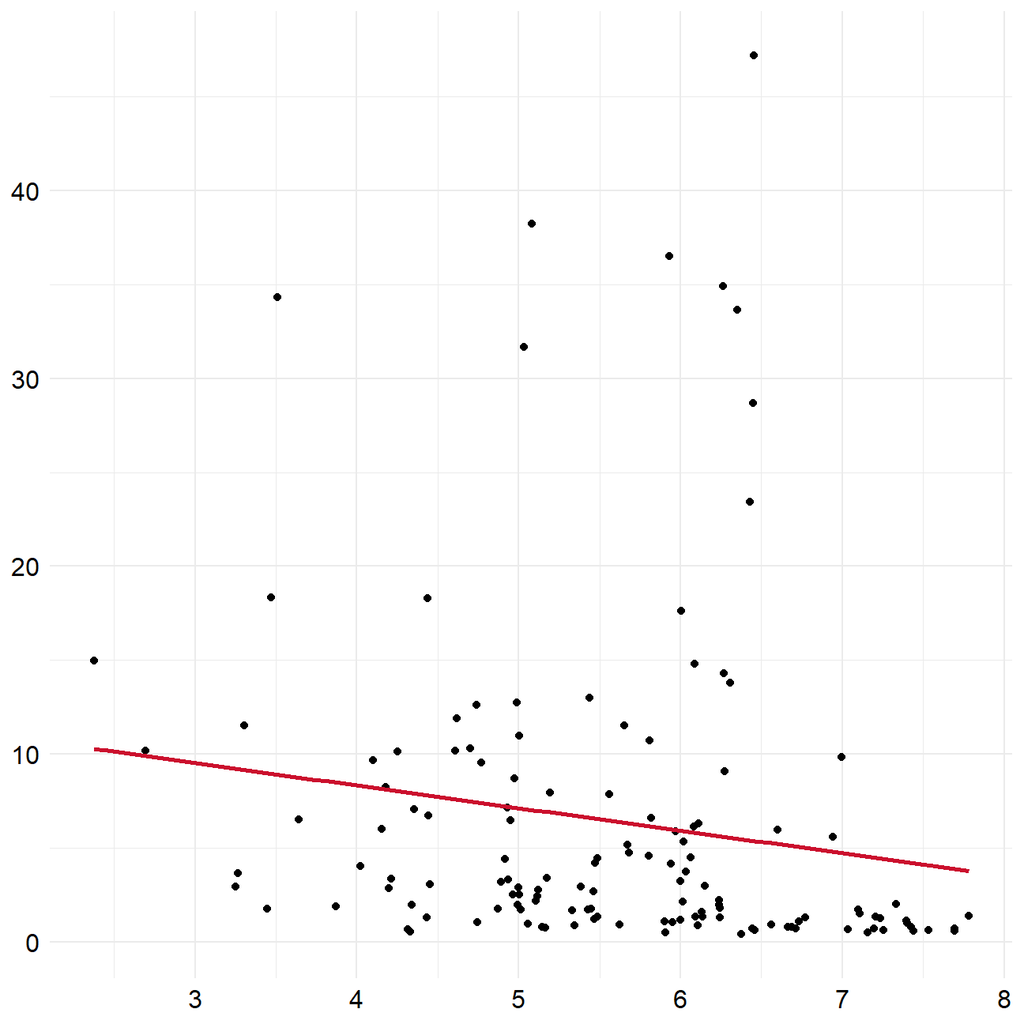

```r
# optimizer blended out as package has same selection method
#full.model <- lm(homicide_rate ~., data = reduced)
#step.model <- stepAIC(full.model, direction = "both",
                      #trace = FALSE)
#summary(step.model)

happiness <- homicide_happiness_gdp %>%
  ggplot(aes(x = life_ladder, y = homicide_rate)) +
  geom_point()+
  geom_smooth(method="lm", se = F, color = "#CB102D")+
  theme_minimal()+
  theme(axis.title.x = element_blank(),
        axis.title.y = element_blank(),
        axis.text=element_text(color = "black", size = 12),
        text=element_text(family="Roboto"),
        plot.caption = element_text(color = "grey", hjust = 0, vjust = -5),
        )

happiness
```

```r
ggsave(file="happiness.svg", plot=happiness, width=8, height=5)
```

## 3.5 Summary for scatter plots

> **The figure shows that all GE destinations where able to decrease homicide rate from 1990 to 2019. However, there are still major gaps between single countries.**

### 3.5.1 1990 vs 2019 global experience countries homicide rates compare

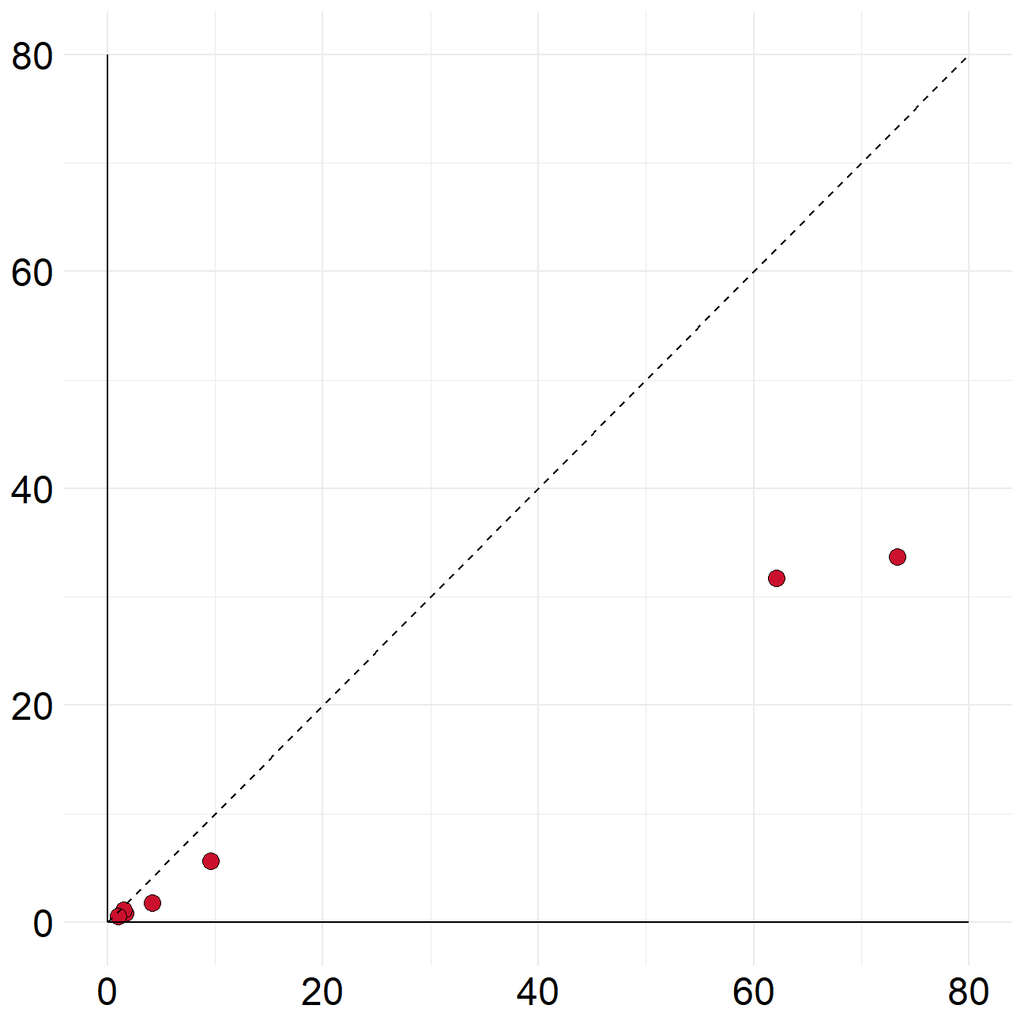

```r
# set filters
years <- c(1990, 2019)
countries <- c("GBR", "USA", "ZAF", "COL", "TUR", "SWE", "FRA")
year_names <- c("year_1990", "year_2019", "year_1990", "year_2019", "year_1990", "year_2019", "year_1990", "year_2019",
                "year_1990", "year_2019", "year_1990", "year_2019", "year_1990", "year_2019")

# clean data
homicide_years <- homicide_raw %>%
  rename(year = year_3) %>%
  rename(homicide_rate = deaths_interpersonal_violence_sex_both_age_age_standardized_rate_4) %>%
  rename(country = entity) %>%
  select(country, code, year, homicide_rate) %>%
  filter(code %in% countries) %>%
  filter(year %in% years) %>%
  mutate(year = year_names)

# transpose data
homicide_years <- homicide_years %>%
  pivot_wider(names_from = year, values_from = homicide_rate)

# plot figure
years_plot <- homicide_years %>%
  ggplot(aes(x = year_1990, y = year_2019, label = country)) +
  geom_point(size = 3.5, alpha = 1, shape = 21, fill = "#CB102D", color = "black")+
  geom_segment(aes(x = 0, y = 0, xend = 80, yend = 80),
               linetype = 2, size = 0.5, color = "black")+
  geom_segment(aes(x = 0, y = 0, xend = 0, yend = 80), size = 0.5, color = "black")+
  geom_segment(aes(x = 0, y = 0, xend = 80, yend = 0), size = 0.5, color = "black")+
  #geom_label_repel()+
  theme_minimal()+
  theme(axis.title.x = element_blank(),
        axis.title.y = element_blank(),
        axis.text=element_text(color = "black", size = 18),
        text=element_text(family="Roboto"),
        plot.caption = element_text(color = "grey", hjust = 0, vjust = -5),
        )

years_plot
```

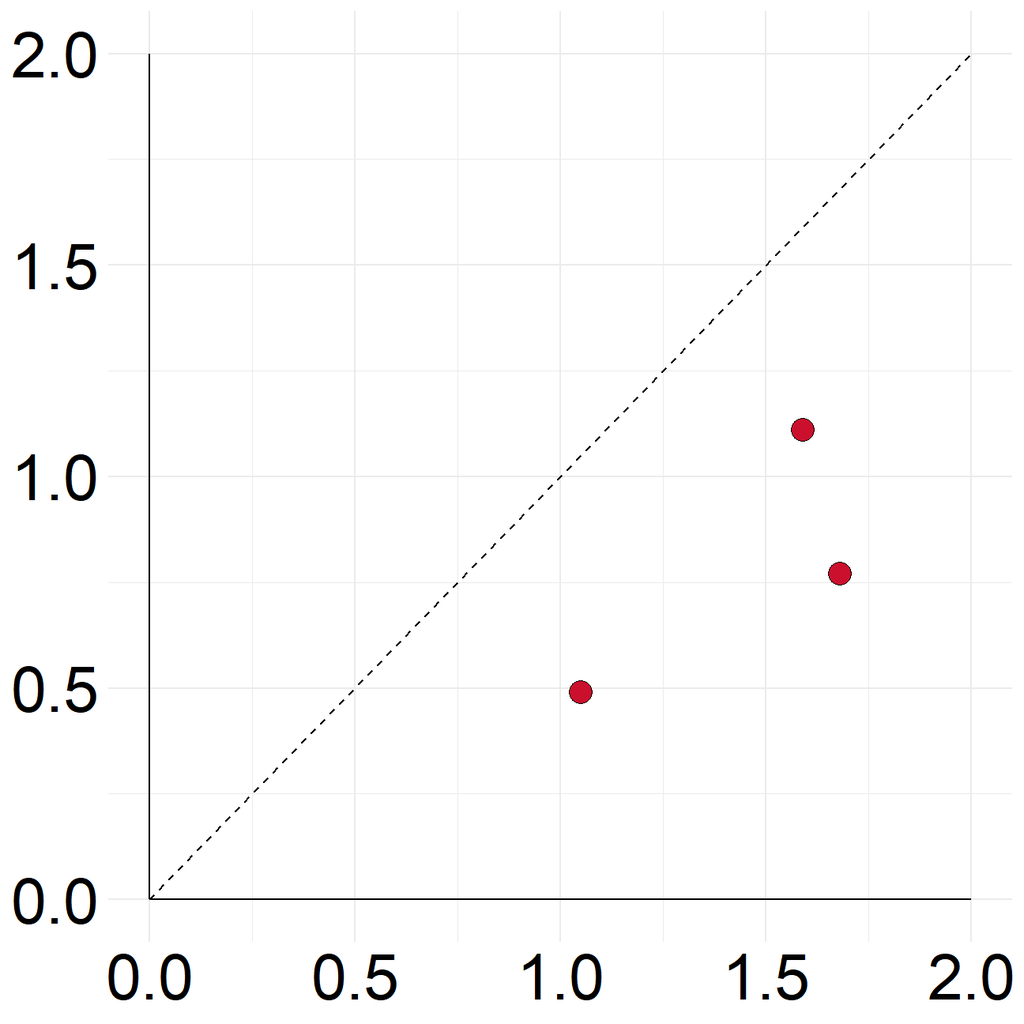

```r
# zoom on european countries
years_plot_zoom <- homicide_years %>%
  ggplot(aes(x = year_1990, y = year_2019, label = country)) +
  geom_point(size = 5, alpha = 1, shape = 21, fill = "#CB102D", color = "black")+
  geom_segment(aes(x = 0, y = 0, xend = 2, yend = 2),
               linetype = 2, size = 0.5, color = "black")+
  geom_segment(aes(x = 0, y = 0, xend = 0, yend = 2), size = 0.5, color = "black")+
  geom_segment(aes(x = 0, y = 0, xend = 2, yend = 0), size = 0.5, color = "black")+
  #geom_label_repel()+
  theme_minimal()+
  theme(axis.title.x = element_blank(),
        axis.title.y = element_blank(),
        axis.text=element_text(color = "black", size = 30),
        text=element_text(family="Roboto"),
        plot.caption = element_text(color = "grey", hjust = 0, vjust = -5),
        )+
  ylim(0,2)+
  xlim(0,2)

years_plot_zoom
```

```r
ggsave(file="years.svg", plot=years_plot, width=7, height=7)
ggsave(file="years_zoom.svg", plot=years_plot_zoom, width=7, height=7)
```

## 3.6 Summary for bar chart (homicide in gender and relationship)

> *The research into this topic revealed a sad reality. While female victims make up only 20 percent of all committed homicides, this figure jumps to over 50 percent for homicides where a relationship to the perpetrator existed (intimate partner or family related).*

### 3.6.1 Calculation for Global experience countries comparison in gender

```r
# Calculate summary statistics for graph
genders <- c("Female", "Male")

# calculate count by gender
gender_all <- homicide_raw_long %>%
  filter(year == 2019) %>%
  filter(dimension == "Total") %>%
  filter(indicator == "Victims of intentional homicide") %>%
  filter(sex %in% genders) %>%
  filter(age == "Total") %>%
  filter(region %in% continents) %>%
  filter(unit_of_measurement == "Counts") %>%
  group_by(sex) %>%
  summarize(homicide_count = sum(value))

# print proportion
percentage_all <- gender_all[1,2]/(gender_all[1,2]+gender_all[2,2])

percentage_all %>%
  rename(proportion_female = homicide_count)
```

```
##   proportion_female
## 1             0.199
```

```r
# calculate count by gender for family member
gender_family <- homicide_raw_long %>%
  filter(year == 2019) %>%
  filter(dimension == "by relationship to perpetrator") %>%
  filter(category == "Intimate partner or family member") %>%
  filter(indicator == "Victims of intentional homicide") %>%
  filter(sex %in% genders) %>%
  filter(age == "Total") %>%
  filter(region %in% continents) %>%
  filter(unit_of_measurement == "Counts") %>%
  group_by(sex) %>%
  summarize(homicide_count = sum(value))

# print proportion
percentage_all <- gender_family[1,2]/(gender_family[1,2]+gender_family[2,2])

percentage_all %>%
  rename(proportion_female_family = homicide_count)
```

```
##   proportion_female_family
## 1                    0.565
```

```r
# calculate same metrics for selected countries
gender_colombia <- homicide_raw_long %>%
  filter(year == 2019) %>%
  filter(country == "Colombia") %>%
  filter(dimension == "Total") %>%
  filter(indicator == "Victims of intentional homicide") %>%
  filter(sex %in% genders) %>%
  filter(age == "Total") %>%
  filter(unit_of_measurement == "Counts") %>%
  group_by(sex) %>%
  summarize(homicide_count = sum(value))

# print proportion
percentage_colombia <- gender_colombia[1,2]/(gender_colombia[1,2]+gender_colombia[2,2])

percentage_colombia %>%
  rename(proportion_female_colombia = homicide_count)
```

```
##   proportion_female_colombia
## 1                     0.0865
```

```r
# calculate same metrics for selected countries
gender_sweden <- homicide_raw_long %>%
  filter(year == 2019) %>%
  filter(country == "Sweden") %>%
  filter(dimension == "Total") %>%
  filter(indicator == "Victims of intentional homicide") %>%
  filter(sex %in% genders) %>%
  filter(age == "Total") %>%
  filter(unit_of_measurement == "Counts") %>%
  group_by(sex) %>%
  summarize(homicide_count = sum(value))

# print proportion
percentage_sweden <- gender_sweden[1,2]/(gender_sweden[1,2]+gender_sweden[2,2])

percentage_sweden %>%
  rename(proportion_female_sweden = homicide_count)
```

```
##   proportion_female_sweden
## 1                    0.225
```

```r
# Create variables for homicide rate country/age group
rate_colombia_49 <- 58.6
rate_sweden_49 <- 1.53

# Calculate rate male in Colombia
rate_gian <- rate_colombia_49*2*9/10 #proportion calculation
rate_gian
```

```
## [1] 105
```

```r
# Calculate rate female in Sweden
rate_vivian <- rate_sweden_49*2*1/5 #proportion calculation
rate_vivian
```

```
## [1] 0.612
```

### 3.6.2 Homicide death amount in age group- bar chart

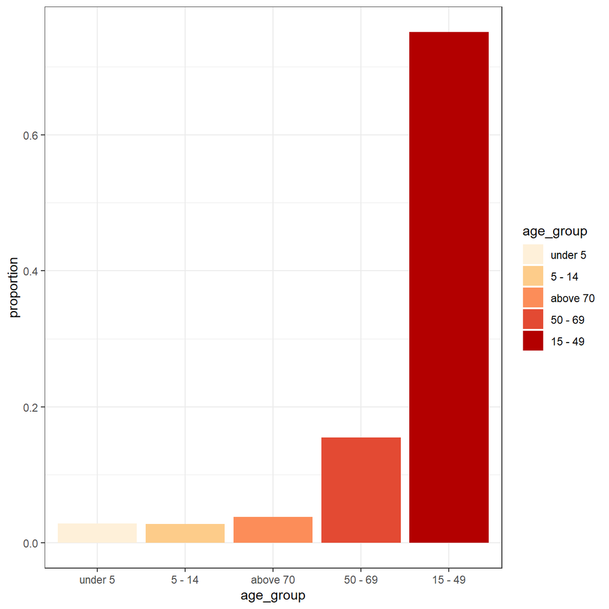

```r
# clean & filter the data for victim and the affected age group and rename columns
victim_age_data <- victim_age_data %>%
                      janitor::clean_names() %>%
                    # rename required columns
                      rename('above 70' = deaths_interpersonal_violence_sex_both_age_70_years_number,
                             "50 - 69" = deaths_interpersonal_violence_sex_both_age_50_69_years_number,
                             "15 - 49" = deaths_interpersonal_violence_sex_both_age_15_49_years_number,
                             "5 - 14" = deaths_interpersonal_violence_sex_both_age_5_14_years_number,
                             "under 5" = deaths_interpersonal_violence_sex_both_age_under_5_number ) %>%
                    #filter for 2019 data
                    filter(year=="2019")

# plot to depict the cases of homicide within each age group around the world in 2019
victim_age_data_long <- victim_age_data %>% pivot_longer(
                                cols = 4:8,
                                names_to = "age_group",
                                values_to = "count"
                              )

victim_age_data_long %>%
  mutate(proportion = count/sum(count)) %>%
  mutate(age_group=fct_reorder(age_group, proportion)) %>%
  ggplot(mapping = aes(x=age_group, y=proportion, fill=age_group)) +
  geom_col()+
  theme_bw()+
  scale_fill_brewer(palette = "OrRd")
```

### 3.6.3 Homicide death amount in age group- ball chart

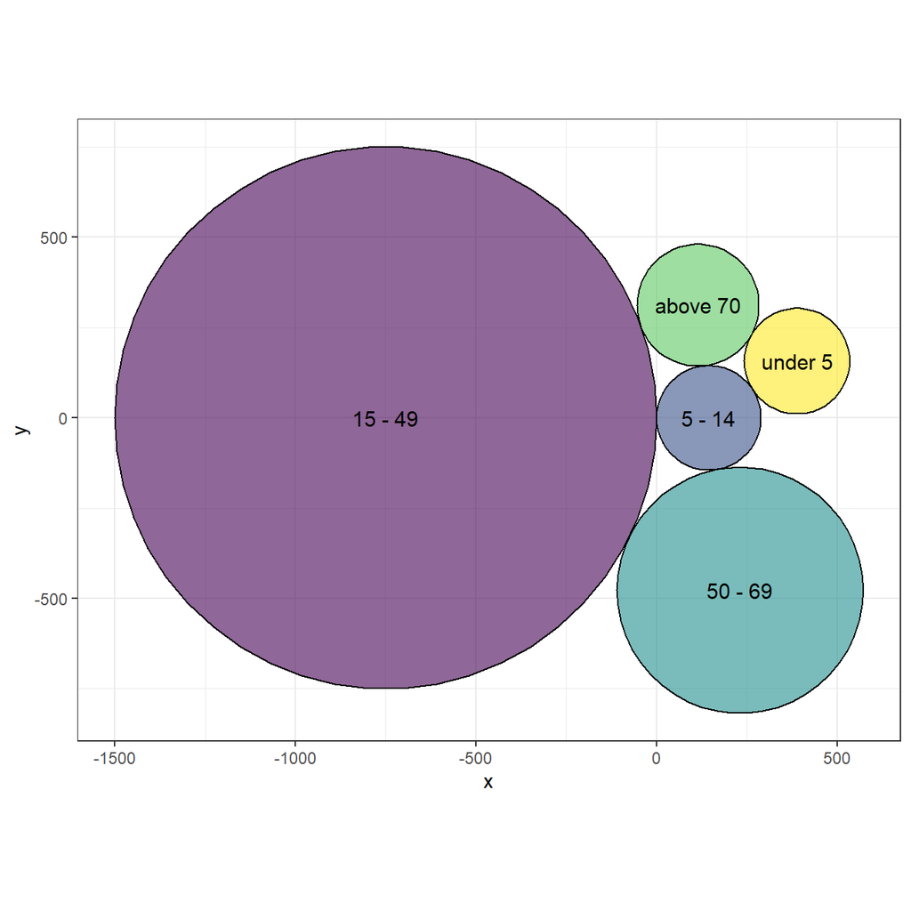

```r
# Create data
data_vic <- victim_age_data_long %>%
  group_by(age_group) %>%
  summarise(count = sum(count))

# Add a column with the text you want to display for each bubble:
data_vic$text <- paste("name: ",data_vic$age_group, "\n", "value:", data_vic$count, "\n", "You can add a story here!")

# Generate the layout
packing <- circleProgressiveLayout(data_vic$count, sizetype='area')
data_vic <- cbind(data_vic, packing)
dat.gg <- circleLayoutVertices(packing, npoints=50)

# Make the plot with a few differences compared to the static version:
p <- ggplot() +
  geom_polygon_interactive(data = dat.gg, aes(x,y,group = id, fill=id,tooltip = data_vic$text[id], data_id = id),colour = "black", alpha = 0.6) +
  scale_fill_viridis() +
  geom_text(data = data_vic, aes(x, y, label = gsub("Group_", "", age_group)), size=4, color="black") +
  theme_void() +
  theme(legend.position="none", plot.margin=unit(c(0,0,0,0),"cm") ) +
  coord_equal()+
  theme_bw()+
   theme(legend.position = "none")

p
```

### 3.6.4 Homicide in gender and relationship

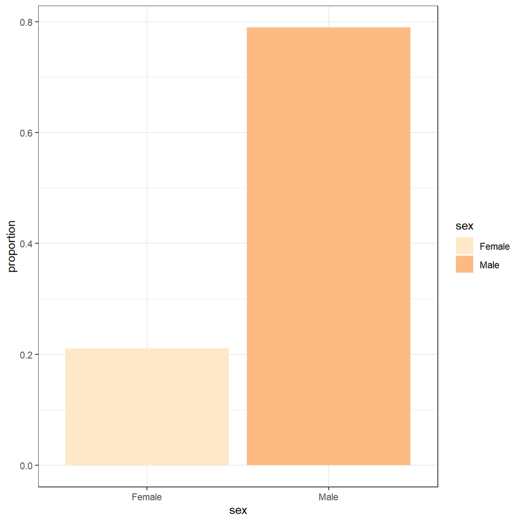

```r
# clean & filter the data for intentional homicide
intentional_homicide_data <- intentional_homicide_data_all %>%
                                      janitor::clean_names() %>%
  #keeping only count data
                                      filter(unit_of_measurement=="Counts") %>%
  #removing unknown and combined data
                                      filter(sex == c("Female","Male")) %>%
  #keeping only overall age data
                                      filter(age=="Total") %>%
  #filter for 2019 data
                                      filter(year=="2019")


# plot to depict homicide share among men and women around the world in 2019
intentional_homicide_data %>%
  mutate(proportion = value/sum(value)) %>%
  mutate(sex=fct_reorder(sex, proportion)) %>%
  ggplot(mapping = aes(x=sex, y=proportion, fill=sex)) +
  geom_col()+
  theme_bw()+
  scale_fill_brewer(palette = "OrRd")
```

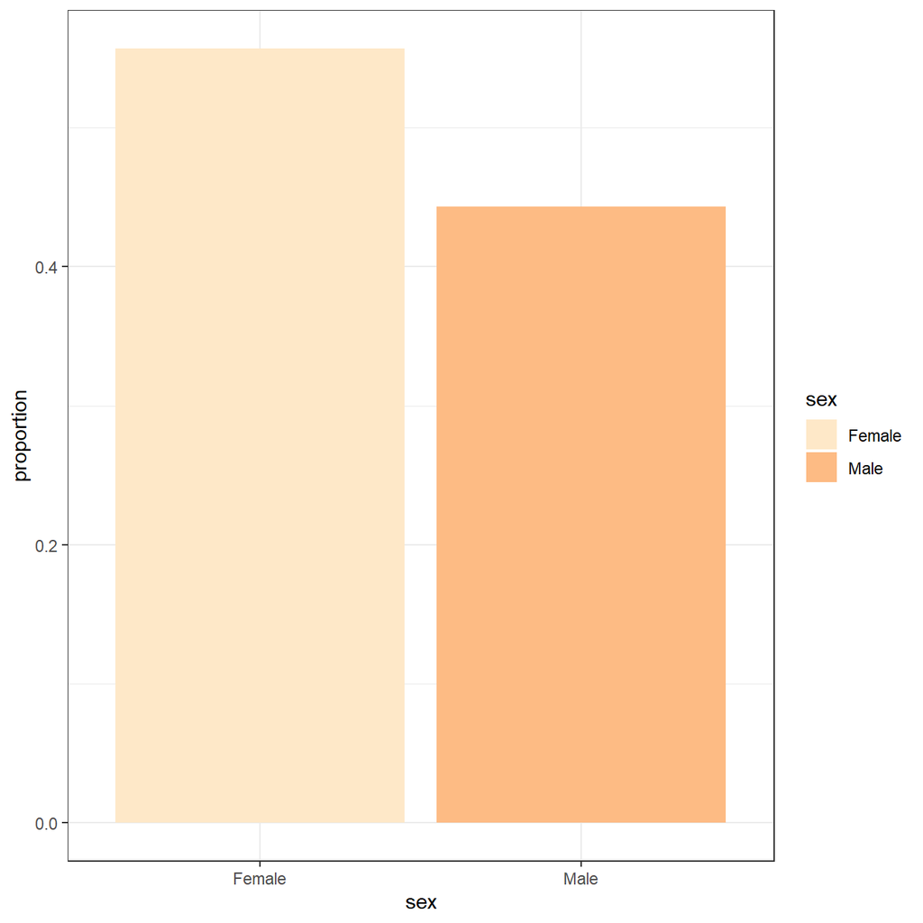

```r
# plot to depict homicide share among men and women around the world in 2019 due to partner or family related homicides
intentional_homicide_data %>%
  filter(category==c("Intimate partner or family member" ,"Intimate partner or family member: Family member" )) %>%
  mutate(proportion = value/sum(value)) %>%
  #mutate(sex=fct_reorder(sex, proportion)) %>%
  ggplot(mapping = aes(x=sex, y=proportion, fill=sex)) +
  geom_col()+
  theme_bw()+
  scale_fill_brewer(palette = "OrRd")
```

# 4 Conclusion for this research

## 4.1 **Learning:**

> *As we moved along the process, we realized the importance of inspecting and cleaning a data set. Real-life data sets are complex and setting them up for data visualizations takes up about 70% of the time. The coding of simple graphs itself takes up the least time.*

## 4.2 **Critique:**

> *We believe we could have had more relevant results had the data been more up to date i.e 2021. There were also some NA values, for which the numbers had to be imputed, thus affecting the accuracy as well. We also observed major discrepancies in the datasets. Lastly, it is believed that the dark figure of homicide is hardly captured.*

## 4.3 **Advise:**

> *Our top advice to our future self and future students is to spend significant amount of time on exploring the data, as it never fails to surprise with interesting insights. It’s important to play with the data-sets and recognize patterns rather than just trying to confirm what one already knows.*

# 5 Information and sources

> − http://ghdx.healthdata.org/gbd-results-tool

> − https://dataunodc.un.org/dp-intentional-homicide-victims

> − https://ourworldindata.org/homicides

> − [https://databank.worldbank.org/source/world-development-indicators](https://databank.worldbank.org/source/world-developmentindicators)